# Historical Men’s College Basketball Insights Using Kenpom Data

Anthony Cunningham

May 3, 2019

# 1 Introduction

Kenpom.com (https://kenpom.com/) contains data on all NCAA Division 1 Men’s Collegiate Basketball teams from 2002-present. This data consists of an offensive, defensive and overall efficiency ratings system, called Adjusted Efficiency Margin, created and updated by the proprietor of this website, Ken Pomeroy. An in-depth explanation of this system can be found here: https://kenpom.com/blog/ratings-explanation/. His work is widely cited in popular sports media, and is used as an evaluation tool in deliberating the selection of teams who may participate in the annual NCAA Men’s Basketball Tournament every March. Additionally, this data also includes basic Win/Loss data, as well as a measure of luck, defined as the difference in a team’s actual vs. expected winning percentage. There is also data on a team’s Strength of Schedule, formed using a team’s opponents’ Adjusted Efficiency Margins.

How are these measures calculated, and what are their interpretations? A team’s Adjusted Offensive Efficiency (“AdjO”) is the number of points a team is predicted to score per 100 possessions against an average team at a neutral site. According to his explanation (found here: https://kenpom.com/blog/national-efficiency/), this is calculated using previous game results, making an adjustment for the pace of a game. Pace is defined as the number of possessions a team has in 40 minutes of game play, the length of a standard collegiate basketball game. A team’s Adjusted Defensive Efficiency (“AdjD”) is the number of points a team is predicted to allow against an average team at a neutral site per 100 possessions. Adjusted Efficiency Marging (“AdjEM”) is the difference between AdjO and AdjD. AdjEM is designed as a predictive tool, aiming to predict the outcome and score of a game. For example, if Team A has an AdjEM of +25, and Team B had an AdjEM of +15, Team A is predicted to win by 10 points if a game is taking place at a neutral site (there is an adjustment for Home-Court Advantage: the home team’s AdjEM increases by 2.8, the visiting team’s AdjEM decreases by the same amount; I do not know how this was determined). With this data, I plan to answer a variety of questions relating to the historical comparisons of basketball teams and how they stack up with one another.

# 2 The Best Teams in Recent College Basketball History

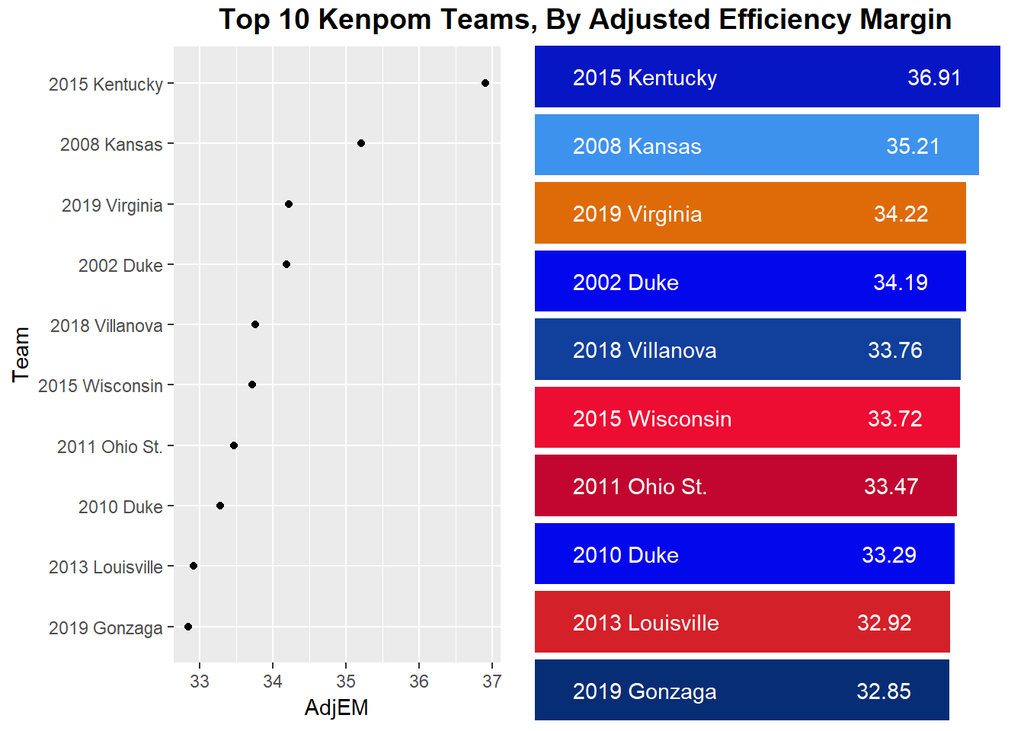

# 3 Ranking the Most Difficult Conferences to Play In

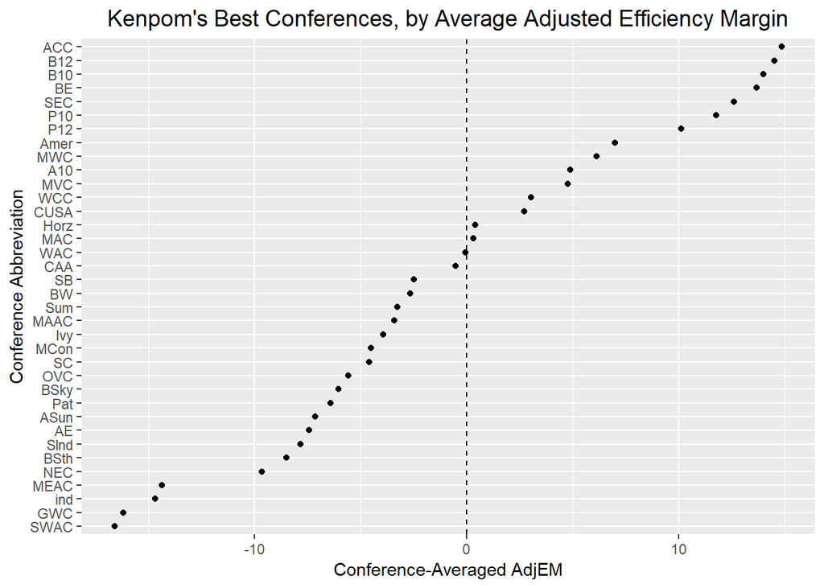

According to Kenpom, the Atlantic Coast Conference (“ACC”) has the best average Adjusted Efficiency Margin among its members from 2002-2019, although the margin is slim, with the Big 12, Big 10 and Big East close behind. How slim are these margins?

Top 4 Conferences in Average AdjEM:

```
## # A tibble: 4 x 2
##   Conf  avg_conf_AdjEM
##   <chr>          <dbl>
## 1 ACC             14.8
## 2 B12             14.5
## 3 B10             14.0
## 4 BE              13.7
```

So, an average ACC team would have been predicted to beat an average Big East team by 1.1 points if this hypothetical game were to take place with each team at the peak of their powers, on a neutral site.

According to the Dot Plot above, there appears to be a significant drop off from the Pacific 12 to the American Athletic Conference. This is consistent with the intuition that there is a large gap in both coaching and player talent, where a small concentration of teams win a higher proportion of games than the vast majority due to these talent advantages. However, it’s worth investigating the trend in competitive balance, as these overall averages may have been impacted by a subsection of years where most of the talent is highly-concentrated. Does this phenomenon still exist, or is coaching and player talent becoming more evenly-distributed? After all, we did witness the 2018 team from tiny Loyola-Chicago advance to the Final Four.

# 4 Trends in Competitive Balance within Men’s College Basketball

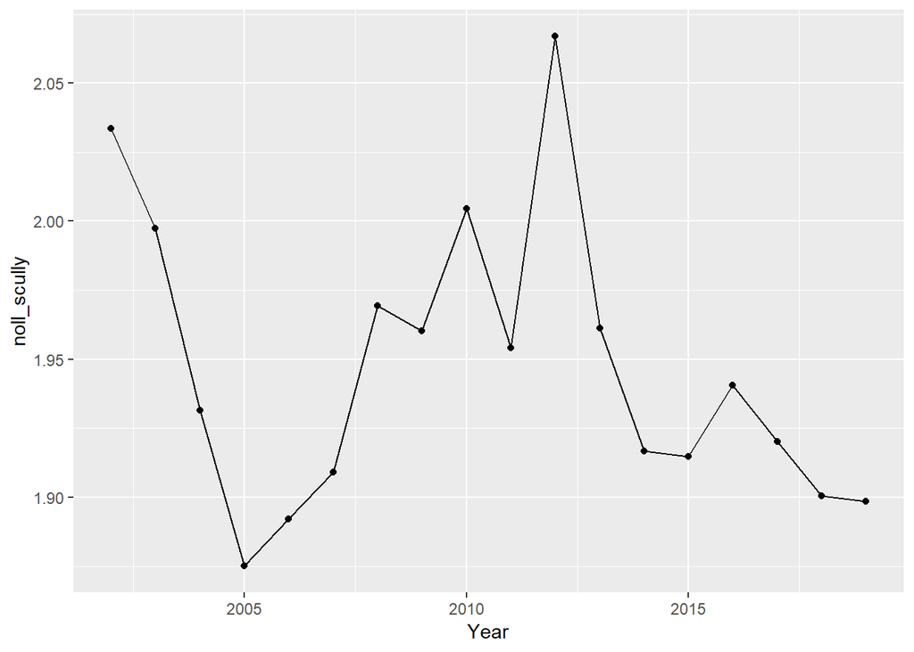

From the limited time period that we have, competitive balance appears to fluctuate between the interval of 1.85 to 2.10. For comparison, the NFL’s average Noll-Scully value is 1.48, while the NBA’s average Noll-Scully value is 2.84, according to Phil Birnbaum (http://blog.philbirnbaum.com/2016/04/noll-scully-doesnt-measure-anything-real.html). So, men’s college basketball appears to have been relatively unbalanced, although not to the extent of their professional counterpart. It is also interesting to note that this Noll-Scully appears to have be somewhat cyclical, with periods of relative unbalance in the early-aughts and early-2010’s, while periods of relative competitive balance occuring during the mid-to-late aughts and the mid-to-late 2010’s. We appear to be in a time of relative balance, as competitive balance for this past season, the just-completed 2019 season, has been the most balanced since 2006. However, this is an admittedly narrow timeframe with which to view and forecast.

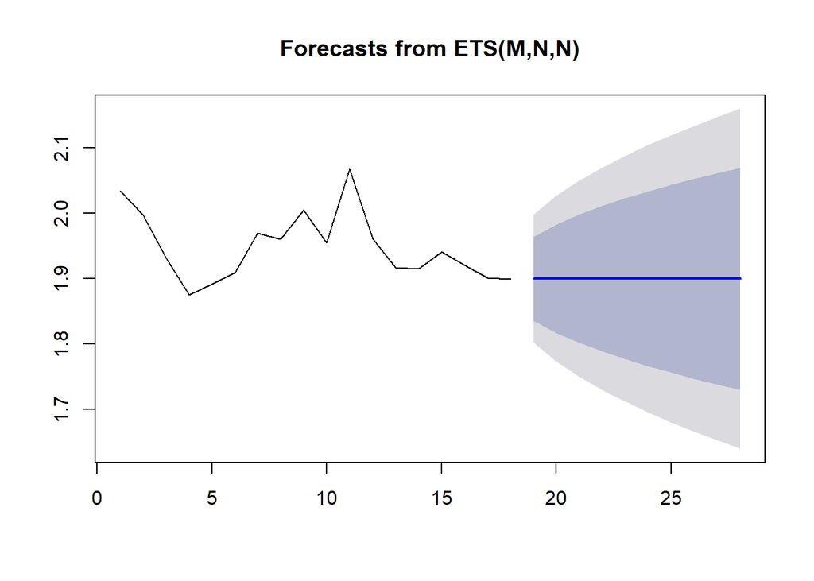

# 5 Resources Used

Birnbaum, Phil, “Noll-Scully doesn’t measure anything real.” Sabermetric Research. from http://blog.philbirnbaum.com/2016/04/noll-scully-doesnt-measure-anything-real.html (accessed April 16, 2019).

Cleonidas, “Remove numbers from alphanumeric characters.” Stack Overflow. from https://stackoverflow.com/questions/13590139/remove-numbers-from-alphanumeric-characters (accessed March 26, 2019).

Fanara, Carlo, “A Tutorial on Loops in R - Usage and Alternatives.” DataCamp. from https://www.datacamp.com/community/tutorials/tutorial-on-loops-in-r (accessed March 26, 2019).

“How to Calculate the Noll-Scully Competitive Balance Measure.” Team Sports Analysis. from http://teamsportsanalysis.blogspot.com/2012/04/how-to-calculate-noll-scully.html (accessed April 11, 2019).

“HTML Color Picker.” Color Code Hex. from https://www.colorcodehex.com/html-color-picker.html (accessed March 31, 2019).

Kassambara, Alboukadel. “ggplot2 - Easy Way to Mix Multiple Graphs on The Same Page.” STHDA. from http://www.sthda.com/english/articles/24-ggpubr-publication-ready-plots/81-ggplot2-easy-way-to-mix-multiple-graphs-on-the-same-page/#arrange-on-one-page (accessed April 2, 2019).